Machine Learning

[figure not shown]

# AI & Machine Learning - Unit 2

### 4. PCA in higher dimension, 3DMM, the curse of dimensionality

**Prof. Iacopo Masi - Computer Science Department, Sapienza University of Rome**

# Recap previous lecture

- Principal Components Analysis (PCA)
- Eigendecomposition of a matrix
- Geometry behind PCA
- Application of PCA for:
  - Compressing the data (point cloud to line)
  - Modeling 3D Faces (3D Morphable Model 3DMM)
  - Rotating the data

# Today's lecture

## PCA with SVD

## PCA in a high dimensional space

## Application: Eigenfaces

## Eigendecomposition of Matrices

$$ \mathbf{W} = \begin{bmatrix} 1 & 1 \\ -1 & 2 \end{bmatrix}, $$

be the matrix where the columns are the eigenvectors of the matrix $\mathbf{A}$. Let

$$ \boldsymbol{\Sigma} = \begin{bmatrix} 1 & 0 \\ 0 & 4 \end{bmatrix}, $$

be the matrix with the associated eigenvalues on the diagonal. Then the definition of eigenvalues and eigenvectors tells us that

$$ \mathbf{A}\mathbf{W} =\mathbf{W} \boldsymbol{\Sigma} . $$

If the matrix $\mathbf{W}$ is invertible, we may multiply both sides by $W^{-1}$ on the right, we see that we may write

$$\mathbf{A} = \mathbf{W} \boldsymbol{\Sigma} \mathbf{W}^{-1}.$$

## Operations on Eigendecompositions

One nice thing about eigendecompositions is that we can write many operations we usually encounter cleanly in terms of the eigendecomposition. As a first example, consider:

$$ \mathbf{A}^n = \overbrace{\mathbf{A}\cdots \mathbf{A}}^{\text{$n$ times}} = \overbrace{(\mathbf{W}\boldsymbol{\Sigma} \mathbf{W}^{-1})\cdots(\mathbf{W}\boldsymbol{\Sigma} \mathbf{W}^{-1})}^{\text{$n$ times}} = \mathbf{W}\overbrace{\boldsymbol{\Sigma}\cdots\boldsymbol{\Sigma}}^{\text{$n$ times}}\mathbf{W}^{-1} = \mathbf{W}\boldsymbol{\Sigma}^n \mathbf{W}^{-1}. $$

This tells us that for any positive power of a matrix, the eigendecomposition is obtained by just raising the eigenvalues to the same power. The same can be shown for negative powers, so if we want to invert a matrix we need only consider

$$ \mathbf{A}^{-1} = \mathbf{W}\boldsymbol{\Sigma}^{-1} \mathbf{W}^{-1}, $$

or in other words, just invert each eigenvalue.

## Eigendecompositions of Symmetric Matrices

- Hessian
- Covariance Matrices*
- PCA*
- Kernels etc

# Eigendecompositions and Singular Value Decomposition

| Method | $\mathbf{A}$ | Decomposition |
| --- | --- | --- |
| SVD | any | $\mathbf{A}=\mathbf{U}\mathbf{\Sigma}\mathbf{V}^T$ |
| Eigen | square | $\mathbf{A}=\mathbf{U}\mathbf{\Sigma}\mathbf{U}^{-1}$ |
| Eigen | square/sym | as above but $\mathbf{U}\mathbf{U}^T=\mathbf{I}$ |

# Decomposition as a Geometric Pipeline

$$\mathbf{A}\mathbf{x} = \underbrace{(\mathbf{U} \underbrace{(\mathbf{\Sigma}\underbrace{(\mathbf{U}^{-1}\mathbf{x})}_{\text{1st step/rotate}})}_{\text{2nd step/scale and flip}})}_{\text{3rd step/rotate}}$$

| Method | Step 1 | Step 2 | Step 3 |
| --- | --- | --- | --- |
| geometry | rotate | scale axis | rotate |
| SVD | $\mathbf{V}^T$ | $\mathbf{\Sigma}$ | $\mathbf{U}$ |
| geometry | rotate | scale axis | rotate back |
| Eig | $\mathbf{U}^{-1}$ | $\mathbf{\Sigma}$ | $\mathbf{U}$ |

# Decomposition as a Geometric Pipeline

# Geometry of SVD

Source: wikipedia

[figure not shown]

# Principal Component Analysis (PCA)

### PCA works in unsupervised learning settings

\begin{equation} \underbrace{\{\mathbf{x}_i\}_{i=1}^N}_{\text{known}} \sim \underbrace{\mathcal{D}}_{\text{unknown}} \end{equation}

### Assumptions

- $\mathbf{x}_i \in \mathbb{R}^D$
- $N \geq D$ (number of points higher than number of features; or else, more points than dimensions)

### Objective: find a transformation (subspace) for compressing the data

### Find the projection that maximizes the spread of the data

- Find $\mathbf{u}\in \mathbb{R}^k$ $\left\|\mathbf{u}\right\|_2=1$ for which you can project the data $\mathbf{x}^{\prime}=\mathbb{P}_{\mathbf{u}}\mathbf{x}$

$$ \mathbb{P}_{\mathbf{u}}\mathbf{x} = (\mathbf{x}^T\mathbf{u})\mathbf{u}$$

- We have to maximize the variance once projected.
- Which means projecting **x** with **u** **large** (U):
- We can measure the **size** of the projection with the $\ell_2$ norm.

$$\arg\max_{\mathbf{u}} \frac{1}{N}\sum_i^N \left\| (\mathbf{x}_i^T\mathbf{u})\mathbf{u}\right\|_2^2$$

# Full recipe

$$ \mathbf{X}^{\prime} \leftarrow \frac{\mathbf{X} - \mathbf{\mu}}{\mathbf{\sigma}} $$$$\underbrace{\mathbf{x}^{T\prime}_p}_{\text{rec}} = \underbrace{\underbrace{\mathbf{U}_{|k}}_{k \mapsto D}\quad\underbrace{\underbrace{\mathbf{U}_{|k}^T}_{D \mapsto k}\quad\underbrace{\mathbf{x}^{T\prime}}_{\text{orig}}}_{projection}}_{reconstruction}$$$$ \mathbf{x}_p\leftarrow\left(\mathbf{x}^{T\prime}_p{\mathbf{\sigma}}\right)+\mathbf{\mu}$$

Can be used for compressing and reconstructing the data using **U** up to *k* components: $$\underbrace{\mathbf{x}^T}_{\text{prj}} = \underbrace{\underbrace{\mathbf{U}_{|k}}_{k \mapsto D}\quad\underbrace{\underbrace{\mathbf{U}_{|k}^T}_{D \mapsto k}\quad\underbrace{\mathbf{x}^T}_{\text{orig}}}_{projection}}_{reconstruction}$$

### Alternative interpretation: Find orthogonal projection that minimizes reconstruction error

$\def\mbf#1{\mathbf{#1}}$

- Find an orthogonal matrix $\mbf{U}\in \mathbb{R}^{D\times k}$ for which:

$$\arg\min_{\mbf{U}} \left\| \mbf{X} - \mbf{U}\mbf{U}^T\mbf{X}\right\|_2^2 \\ \text{subject to} \quad \mbf{U}^T\mbf{U} = \mbf{I_k} $$

- Both interpretations lead to the same results:
  - To compute $\mbf{U}$ you have to compute Eigendecomposition of covariance matrix $\frac{1}{N}\mbf{X}\mbf{X}^T$

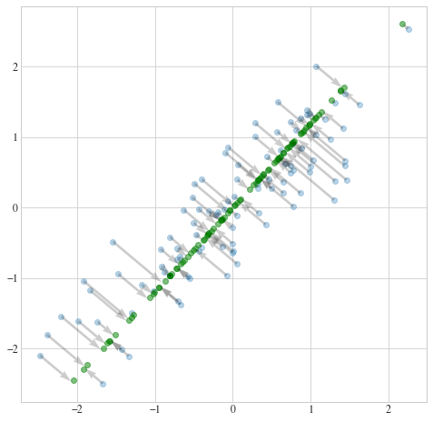

## What happens if input dimensionality is large?

- $\mbf{X} \in \mathbb{R}^{D\times N}$ then $\mathbb{Cov} = \frac{1}{N}\mbf{X}\mbf{X}^T$ is a **big** matrix.
- $D \gg N$

What is the shape of $\mathbb{Cov}$?

- $\mathbb{Cov} \in \mathbb{R}^{D\times D}$.
- Eigendecomposition complexity $\mathcal{O}(D^3)$ so, in our case, if $D$ is large **we have a computational problem.**

# What happens in high dimensions?

- Are we supposed to think about the world in a 3-dimensional space?
- Our brain can think in a 3-dimensional world.
- Maybe with relativity theory, we arrive at a 4-D space if we also consider time.
- **So why do we need higher dimensions?**

# High Dimensional Space

- Visualizing one-hundred-dimensional space is incredibly difficult for humans.
- Most of the time the representation for an input datum is a vector in **high dimensional space.**
- You can think of an image $\mathbf{I}\in \mathbb{R}^{WxH}$ as a point/vector in high dimension.
- For an image $128\times 128$ now our $D$ dimension is very high. $D=128^2=(2^7)^2=2^{14}\approx16K$
- Let's double the image $128 \mapsto 256$
- For an image $256\times 256$ now our $D$ dimension is very high. $D=256^2=(2^8)^2=2^{16}\approx65K$
- Doubling a side increases the dimension four times, due to the two-dimensional nature of images.
- So you can consider an image as a $65K$-dimensional vector!

## Let's practice with 2D real data

We will pull a 2D real dataset made of images in the wild using `sklearn`

```python
from sklearn.datasets import fetch_lfw_people
faces = fetch_lfw_people(min_faces_per_person=60)
print(faces.target_names)
print(faces.images.shape)
```

```
['Ariel Sharon' 'Colin Powell' 'Donald Rumsfeld' 'George W Bush'
 'Gerhard Schroeder' 'Hugo Chavez' 'Junichiro Koizumi' 'Tony Blair']
(1348, 62, 47)
```

```python
faces.images[0,...].shape
```

```
(62, 47)
```

## Best Practice: Always look at the data before you start working!

- Do not do simple summary statistics on the dataset
- Always look at large random samples of the dataset
- The data may **contain noise** that you want to be aware of!
- Do not take for granted that the data **and** the labels are noise-free
- You could try to plot the data to a lower dimension also (i.e. with PCA)

In total we have `(1348, 62, 47)` so `1348` images of dimension `62x47 = 2914`.

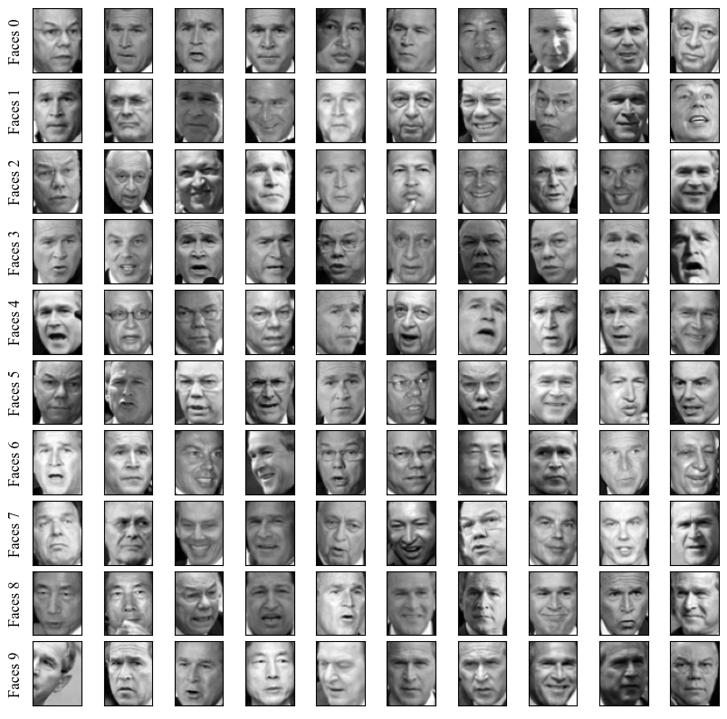

```python
# Plot the faces
N_ax, N_img = 10, 10 #10 rows with 10 images per row
fig, ax = plt.subplots(N_ax, N_img,figsize=(10,10),
                       subplot_kw={'xticks':[], 'yticks':[]},
                       gridspec_kw=dict(hspace=0.1, wspace=0.1))
for i in range(N_ax):
    ax[i,0].set_ylabel(f'Faces {i}')
    for j in range(N_img):
        ax[i,j].imshow(faces.data[i*N_img+j].reshape(62, 47), cmap='gray')
```

## For example, what is this?

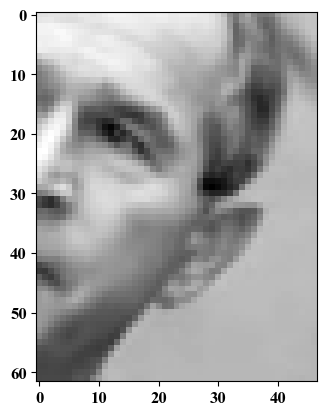

```python
plt.imshow(faces.data[9*N_img].reshape(62, 47), cmap='gray')
```

- Looks like a misalignment error!
- This can create noise in PCA estimation

# 2D images are high-dimensional vectors

- We said faces are vectors that live in a $\mathbb{[0,255]}^{2914}$, if you flatten the dimensions
- Now how many images can you draw in this space, assuming the grayscale values are $[0,\ldots,255]$?

$$256^{H\times W}=256^{2914} \approx 10^{7018}$$